# Module 03: Data manipulation with R

In this module we are going to see how to manipulate, subset and modify tables using `dplyr`, which is also a part of the `tidyverse` package family.

We will learn how to:

- select columns in a table
- filter a table based on certain conditions
- combine data manipulation and plotting
- summarise data across groups

First let’s load the `tidyverse` package and read the data that we will work on:

```r
library(tidyverse)

# Read data using read_csv
expt1 <- read_csv("../course_data/burghardt_et_al_2015_expt1.csv")
```

### Selecting columns with `select()`

To get an idea of data contents we will first check number of dimentsions with `dim()` and look at the column names with `names()`.

```r
dim(expt1)
```

```
## [1] 957  15
```

```r
names(expt1)
```

```
##  [1] "genotype"             "background"           "temperature"
##  [4] "fluctuation"          "day.length"           "vernalization"
##  [7] "survival.bolt"        "bolt"                 "days.to.bolt"
## [10] "days.to.flower"       "rosette.leaf.num"     "cauline.leaf.num"
## [13] "blade.length.mm"      "total.leaf.length.mm" "blade.ratio"
```

This is quite a large dataset, we don’t want to look at it all at once. Say, we are interested in just 2 columns for now: `genotype` and `temperature`. To select the columns we will use `select()`, ironically.

```r
expt1.genot.temp <- select(expt1, genotype, temperature)
expt1.genot.temp
```

```
## # A tibble: 957 x 2
##    genotype temperature
##       <chr>       <int>
##  1  Col Ama          12
##  2  Col Ama          12
##  3  Col Ama          12
##  4  Col Ama          12
##  5  Col Ama          12
##  6  Col Ama          12
##  7  Col Ama          12
##  8  Col Ama          12
##  9  Col Ama          12
## 10  Col Ama          12
## # ... with 947 more rows
```

This was easy. Let’s say we wanted to select the column `genotype` and any column that contains the word “bolt” in its name. `select()` allows you to do this:

```r
expt1.bolt <- select(expt1, genotype, contains("bolt"))
expt1.bolt
```

```
## # A tibble: 957 x 4
##    genotype survival.bolt  bolt days.to.bolt
##       <chr>         <chr> <chr>        <int>
##  1  Col Ama             Y     Y           28
##  2  Col Ama             Y     Y           29
##  3  Col Ama             Y     Y           31
##  4  Col Ama             Y     Y           31
##  5  Col Ama             Y     Y           32
##  6  Col Ama             Y     Y           33
##  7  Col Ama             Y     Y           34
##  8  Col Ama             Y     Y           35
##  9  Col Ama             Y     Y           69
## 10  Col Ama             Y     Y           72
## # ... with 947 more rows
```

> **Challenge**: can you select all the columns that contain values measured in mm?

### Filter rows according to certain conditions with `filter()`

Let’s say that we wanted to retain only the rows of our table with data on vernalized plants. This is a job for the `filter()` function. Before the filetering we need to have a look at the possible values in the `vernalization` column, there are only 2 possibilities: ‘V’ and ‘NV’.

```r
unique(expt1$vernalization)
```

```
## [1] "NV" "V"
```

Since we are intereseted in veranlized plants only, so will be selected only “V”s:

```r
expt1.vernalised <- filter(expt1, vernalization == "V")
expt1.vernalised
```

```
## # A tibble: 330 x 15
##    genotype background temperature fluctuation day.length vernalization
##       <chr>      <chr>       <int>       <chr>      <int>         <chr>
##  1  Col Ama        Col          12         Con         16             V
##  2  Col Ama        Col          12         Con         16             V
##  3  Col Ama        Col          12         Con         16             V
##  4  Col Ama        Col          12         Con         16             V
##  5  Col Ama        Col          12         Con         16             V
##  6  Col Ama        Col          12         Con         16             V
##  7  Col Ama        Col          12         Con         16             V
##  8  Col Ama        Col          12         Con         16             V
##  9  Col Ama        Col          12         Con          8             V
## 10  Col Ama        Col          12         Con          8             V
## # ... with 320 more rows, and 9 more variables: survival.bolt <chr>,
## #   bolt <chr>, days.to.bolt <int>, days.to.flower <int>,
## #   rosette.leaf.num <int>, cauline.leaf.num <int>, blade.length.mm <dbl>,
## #   total.leaf.length.mm <dbl>, blade.ratio <dbl>
```

To set the filtering conditions, several operators can be used:

- `<` less than
- `<=` less than or equal to
- `>` more than
- `>=` more than or equal to
- `==` equal to
- `!=` not equal to

It is also possible to combine several conditions together using the following operators:

- `&` for AND
- `|` for OR

We can also identify missing values (`NA`) using:

- `is.na()` is missing
- `!is.na()` is *not* missing

For example, if we want to select individuals that were vernalized and grown under fluctuating temperature conditions, we could do:

```r
expt1.vernalised.fluctuating <- filter(expt1, vernalization == "V" & fluctuation == "Var")
```

Another example, if we wanted to select individuals grown with 8h day light or that were late flowering:

```r
expt1.SD.or.late <- filter(expt1, day.length == "8" | days.to.bolt > 85)
```

> **Exercise** Can you filter the data to keep the following?
> 1. Samples that are **not in the the Ler background** and that have been treated with **fluctuating temperature**.
> 2. Samples that are bolting at less than **57 days** of flowing with **less than > 40 leaves**
> 3. Samples of genotypes `fca-6` for which `blade.ratio` is not missing

```r
# Enter your code here
```

### Modify or add new columns with `mutate()`

This is a useful function to add new variables (i.e. new columns) to the table, or to modify existing ones. Say, we want to add a new column, `blade.length.cm` which will contain blade length measeured in cm. We can construct this column by modifying the already existing `blade.length.mm` column.

```r
dim(expt1)
```

```
## [1] 957  15
```

```r
expt1.cm <- mutate(expt1, blade.length.cm = blade.length.mm/10)
dim(expt1.cm)
```

```
## [1] 957  16
```

We can also modify/create more than one variable at a time, separating them by `,`:

```r
expt1.cm <- mutate(expt1, blade.length.cm = blade.length.mm/10,
                   total.leaf.length.cm = total.leaf.length.mm/10)
```

**Be careful!** If we use the name of an existing variable, it will modify it instead.

### Chain commands with `%>%` pipes

It allows to perform a sequence of multiple operations, without a need for intermediate files (or very complicated nested command lines).

Now let’s say that we wanted to do several manipulations in our data.frame:

- Create a new column containing total leaf length in cm
- Filter our data so that it only contains vernalised plants
- Retain only two columns from our table: genotype and total leaf length in cm

Based on what we’ve learned so far, we could for example do the following:

```r
expt1.filtered <- mutate(expt1,
                         total.leaf.length.cm = total.leaf.length.mm/10)

expt1.filtered <- filter(expt1.filtered,
                         vernalization == "V")

expt1.filtered <- select (expt1.filtered,
                          genotype,
                          total.leaf.length.cm )
```

`dplyr` allows us to “chain” several commands using a special “pipe” function `%>%`. This is how the above code could have been written using this trick:

```r
expt1 %>%
  mutate(total.leaf.length.cm = total.leaf.length.mm/10) %>%
  filter(vernalization == "V") %>%
  select(genotype, total.leaf.length.cm)
```

```
## # A tibble: 330 x 2
##    genotype total.leaf.length.cm
##       <chr>                <dbl>
##  1  Col Ama                 2.21
##  2  Col Ama                 2.68
##  3  Col Ama                 2.79
##  4  Col Ama                 2.28
##  5  Col Ama                 2.49
##  6  Col Ama                 2.22
##  7  Col Ama                 2.41
##  8  Col Ama                 2.14
##  9  Col Ama                 3.60
## 10  Col Ama                 2.99
## # ... with 320 more rows
```

> **Exercise:** Use `%>%` to do the following on expt1:
> - Keep samples that are not in the the Ler background and that have been treated with fluctuating temperature.
> - Transform the blade length in cm
> - Keep only the columns containing information about the genotype, blade length (in cm) and bolting information (hint, use `contains`)

```r
# Enter your code here
```

### Combine all the above with graphs

We can pipe data manipulation with `ggplot` to produce graphs for a subset of the data. Let’s say we want to make a boxplot of the flowering time in function if the temperature fluctuation (like in last session), however only for the vernalised samples. For this, we can use the following code:

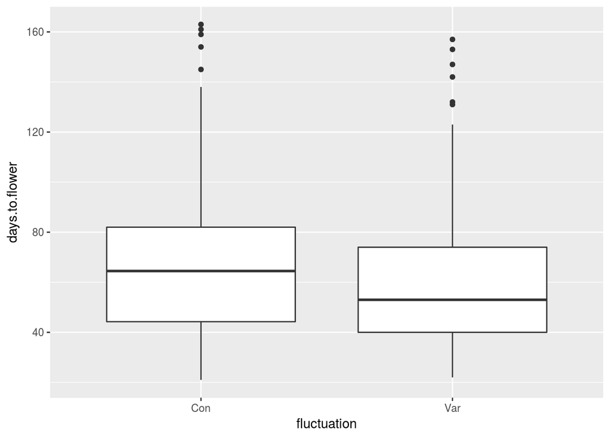

```r
expt1 %>%
  filter(vernalization == "V") %>%
  ggplot(aes(fluctuation, days.to.flower)) +
  geom_boxplot()
```

> **Exercise** Can you make a violin plot of the days to flower for the different genotypes that have been growing in short days?

```r
# Enter your code here
```

### Summarise data with `group_by` and `summarise`

Sometimes we might want to summarise our data in a smaller table. This kind of operation can be achieved by combining two `dplyr` functions: `group_by()` and `summarise()`.

For example, we can summarise the mean flowering time for each genotype:

```r
expt1 %>%
  group_by(genotype) %>%
  summarise(mean.days.to.flower = mean(days.to.flower, na.rm = TRUE))
```

```
## # A tibble: 10 x 2
##      genotype mean.days.to.flower
##         <chr>               <dbl>
##  1    Col Ama            55.82836
##  2    Col FRI            70.19167
##  3      fca-6            70.45000
##  4  flc-3 FRI            53.13333
##  5      flk-1            77.55769
##  6      fve-3            81.25000
##  7       ld-1            89.76471
##  8      Ler-1            55.64706
##  9  prmt5 FRI            88.67925
## 10 vin3-4 FRI            95.67000
```

# Saving data to a file

Once we have modified our data we might want to save it to come back to it later. For this we can use the function `write_csv()`

Let’s say that we were to remove all the missing data from our data to share it with a collaborator (or later use in R ourselves):

```r
expt1.blade.ratio.clean <- expt1 %>%
  filter(!is.na(blade.ratio))

write_csv(expt1.blade.ratio.clean, path = "x_blade_ratio_clean.csv")
```

### Some key points to remember

- `dplyr` has several useful functions to manipulate tables
- `dplyr` functions can be “chained” together using the `%>%` pipe
- We can save tables to text-based files using the `write_*` family of functions

### Futher reading and additional resources:

- [dplyr cheat sheet](https://www.rstudio.com/wp-content/uploads/2015/02/data-wrangling-cheatsheet.pdf)
- [data transformation chapter from ‘R for Data Science’](http://r4ds.had.co.nz/transform.html)